# Model Basics

J. J. Fain

9/21/2021

```r
library(tidyverse)
library(tidymodels)
library(datasets)
library(magrittr)
```

# Getting Started

We first need to decide what dataset(s) we want to play with today. I’m partial to the Iris and Motor Trend Cars dataset for demos. Relationships are fairly intuitive in these data which helps us to know when we have made a mistake in our model. Also, these seem to be among the most popular datasets for introducing R which means you can find a ton of examples online which expand on the analyses we will do here.

## First Principles

In R we define formulas using the notation y ~ x<sub>1</sub>+x<sub>2</sub>+…x<sub>n</sub> where y (the left-hand side or “lhs”) is the response and the x variables (the right-hand side or “rhs”) are the predictors. The tilde (~) is used here in place of the equals sign mostly to set formulas apart from variable assignments since R uses both = and <- for that purpose. However, it may be useful to think of the tilde as a stand-in for “approximately equal” since the predictors are not usually perfectly correlated to, but rather seek to approximate the true distribution of the response.

While the addition symbol (+) is most common for adding variables to the predictor side, some other infix operators get special use in model equations [^1] To specify an interaction term, you can use the semicolon (:) between the interacting variables. When we want to include all of the predictors in our model we can use a period (.) as a stand-in. The cross of two variables (their individual effects plus their interaction) you can use the multiplication asterisk (*). The cross of two variables *a* and *b*[^2] is equivalent to `y~a+b+a:b`. Similar in its unnecessary redundancy is the construct `y~1` because for all non-polynomial regressions this is equivalent to `mean(y)`. Also, `y~1+x` could be translated as “y as explained by x, without respect to $\hat{x}$.”

### The Model Maxims

I always try to operate on two maxims when making models:

1. *The perfect is the enemy of the good*
2. *Do everything you can to attempt to prove yourself wrong*

Maxim 1 tells us that we should err on the side of making models that are only *decent* predictors. Keep it simple and you will save yourself a lot of headache trying to prove you haven’t overfitted the model later on. Machine learning is a perfect example of an approach which violates this maxim and precisely why NN[^3] validation takes so much longer than training.

Maxim 2 is essentially building your steelman from straw. In philosophy, a “straw man” argument is the act of taking the weakest version of your opponents’ argument and proving it false. Obviously that’s easy to do. The opposite of the straw man – a steelman – is where you take the *strongest* version of your opponents’ argument and prove **that** false. The point of peer review is to find and exploit any weaknesses in your methods and no single model or test will satisfy everyone. Instead, take every opportunity to approach your problem from a new angle and be certain that the results tell the same story.

## Now for Something Interesting

Since we have all of the boring syntax and my personal philosophy out of the way, we can get into doing actual models.

#### Data First

Let’s load the datasets with reasonable names. These are from the package `{datasets}` which I’m almost certain ships with the R `{base}` package now, but if you get an error just install `{datasets}` in the usual way.

```r
mt <- mtcars
chicks <- ChickWeight
```

### EDA

One of the phrases/acronyms I throw around a lot is **EDA** which stands for “Exploratory Data Analysis*. I describe this to non-science people as”poking at the data until something interesting falls out" and that is essentially what it is. In this phase we just try anything we can think of and follow any lines of inquiry that we find.

Usually I do the analysis and then give you clean examples with all of the bugs worked out. That deprives you of seeing my actual thoughT process, so this is how I worked out the examples you will have seen above. I’m not going to delete any mistakes or do any editing to my code other than to write comments. This is exactly what my work would look like if I were given these datasets for the first time.

```r
glimpse(mt)
```

```
## Rows: 32
## Columns: 11
## $ mpg  <dbl> 21.0, 21.0, 22.8, 21.4, 18.7, 18.1, 14.3, 24.4, 22.8, 19.2, 17.8,…
## $ cyl  <dbl> 6, 6, 4, 6, 8, 6, 8, 4, 4, 6, 6, 8, 8, 8, 8, 8, 8, 4, 4, 4, 4, 8,…
## $ disp <dbl> 160.0, 160.0, 108.0, 258.0, 360.0, 225.0, 360.0, 146.7, 140.8, 16…
## $ hp   <dbl> 110, 110, 93, 110, 175, 105, 245, 62, 95, 123, 123, 180, 180, 180…
## $ drat <dbl> 3.90, 3.90, 3.85, 3.08, 3.15, 2.76, 3.21, 3.69, 3.92, 3.92, 3.92,…
## $ wt   <dbl> 2.620, 2.875, 2.320, 3.215, 3.440, 3.460, 3.570, 3.190, 3.150, 3.…
## $ qsec <dbl> 16.46, 17.02, 18.61, 19.44, 17.02, 20.22, 15.84, 20.00, 22.90, 18…
## $ vs   <dbl> 0, 0, 1, 1, 0, 1, 0, 1, 1, 1, 1, 0, 0, 0, 0, 0, 0, 1, 1, 1, 1, 0,…
## $ am   <dbl> 1, 1, 1, 0, 0, 0, 0, 0, 0, 0, 0, 0, 0, 0, 0, 0, 0, 1, 1, 1, 0, 0,…
## $ gear <dbl> 4, 4, 4, 3, 3, 3, 3, 4, 4, 4, 4, 3, 3, 3, 3, 3, 3, 4, 4, 4, 3, 3,…
## $ carb <dbl> 4, 4, 1, 1, 2, 1, 4, 2, 2, 4, 4, 3, 3, 3, 4, 4, 4, 1, 2, 1, 1, 2,…
```

```r
glimpse(chicks)
```

```
## Rows: 578
## Columns: 4
## $ weight <dbl> 42, 51, 59, 64, 76, 93, 106, 125, 149, 171, 199, 205, 40, 49, 5…
## $ Time   <dbl> 0, 2, 4, 6, 8, 10, 12, 14, 16, 18, 20, 21, 0, 2, 4, 6, 8, 10, 1…
## $ Chick  <ord> 1, 1, 1, 1, 1, 1, 1, 1, 1, 1, 1, 1, 2, 2, 2, 2, 2, 2, 2, 2, 2, …
## $ Diet   <fct> 1, 1, 1, 1, 1, 1, 1, 1, 1, 1, 1, 1, 1, 1, 1, 1, 1, 1, 1, 1, 1, …
```

Cool. We have names to work with, and I checked out the specifications for each column just by running `mtcars`. To be fair, the mtcars dataset is pretty hard to understand, especially since a lot of the categorical data is coded as numeric and the column names aren’t intuitive.

##### MT Cars

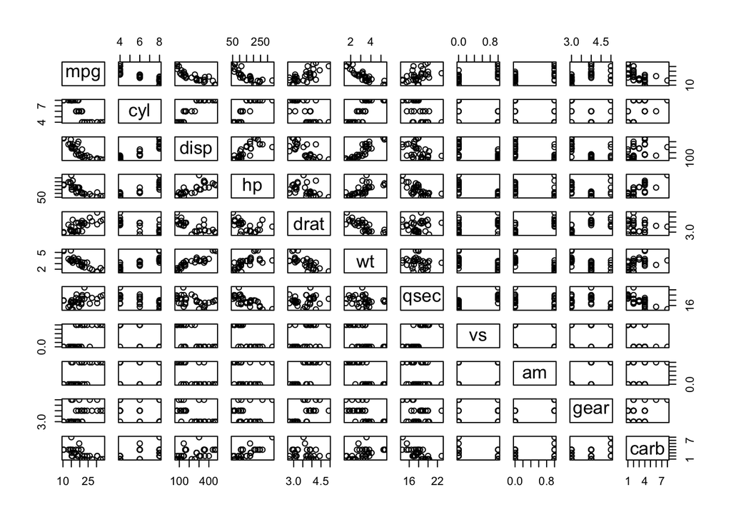

```r
plot(mt)
```

That is way too much to look at and nothing really sticks out to me as being useful. Some of the variables are discrete while some are continuous and others are numerically coded categorical variables. Moving forward, let’s assume we are looking at factors affecting the fuel efficiency (mpg).

It is reasonable to assume that the displacement has something to do with fuel efficiency since displacement is a measure of fuel-air volume across all cylinders. I *think* that this should be mostly correclated with the number of cyinders in an engine, but maybe displacement is normalized for the number of cylinders.

We will fit a linear model AND do an analysis of variance on the cross between displacement and cylinders relative to mpg to see what sort of relationships we get. Note: The T-pipe is here again. I use it a lot when I am doing EDA to get two analyses out of one pipe.

```r
lm(mpg~cyl*disp, data = mt) %T>%
  print() %>%
  anova
```

```
##
## Call:
## lm(formula = mpg ~ cyl * disp, data = mt)
##
## Coefficients:
## (Intercept)          cyl         disp     cyl:disp
##    49.03721     -3.40524     -0.14553      0.01585
```

```
## Analysis of Variance Table
##
## Response: mpg
##           Df Sum Sq Mean Sq  F value    Pr(>F)
## cyl        1 817.71  817.71 115.5772 1.902e-11 ***
## disp       1  37.59   37.59   5.3136  0.028784 *
## cyl:disp   1  72.64   72.64  10.2670  0.003369 **
## Residuals 28 198.10    7.08
## ---
## Signif. codes:  0 '***' 0.001 '**' 0.01 '*' 0.05 '.' 0.1 ' ' 1
```

Alright! We get a very strong response from the ANOVA showing that we are on the right track by assuming that the number of cylinders and engine displacement have some impact on fuel efficiency. The raw output from the linear model confirms that the number of cylinders has the strongest (negative) impact on fuel efficiency. The cross between them is so small as to indicate that they are just closely correlated. That is to say that the `disp` variable is not controlled for the `cyl` variable and thus probably have a strong correlation (more cylinders means greater displacement.) We can check that easily.

```r
with(mt, cor(cyl, disp))
```

```
## [1] 0.9020329
```

Yep. Just as expected. the `cyl` and `disp` variables are so closely linked that we don’t really need to worry about them both making it into a model. If we were bothered with AIC, PLS, or PCA, we would throw them into a single component, but this is meant to be model basics so I will stop short of that for now.

Remind me of the variable names

```r
glimpse(mt)
```

```
## Rows: 32
## Columns: 11
## $ mpg  <dbl> 21.0, 21.0, 22.8, 21.4, 18.7, 18.1, 14.3, 24.4, 22.8, 19.2, 17.8,…
## $ cyl  <dbl> 6, 6, 4, 6, 8, 6, 8, 4, 4, 6, 6, 8, 8, 8, 8, 8, 8, 4, 4, 4, 4, 8,…
## $ disp <dbl> 160.0, 160.0, 108.0, 258.0, 360.0, 225.0, 360.0, 146.7, 140.8, 16…
## $ hp   <dbl> 110, 110, 93, 110, 175, 105, 245, 62, 95, 123, 123, 180, 180, 180…
## $ drat <dbl> 3.90, 3.90, 3.85, 3.08, 3.15, 2.76, 3.21, 3.69, 3.92, 3.92, 3.92,…
## $ wt   <dbl> 2.620, 2.875, 2.320, 3.215, 3.440, 3.460, 3.570, 3.190, 3.150, 3.…
## $ qsec <dbl> 16.46, 17.02, 18.61, 19.44, 17.02, 20.22, 15.84, 20.00, 22.90, 18…
## $ vs   <dbl> 0, 0, 1, 1, 0, 1, 0, 1, 1, 1, 1, 0, 0, 0, 0, 0, 0, 1, 1, 1, 1, 0,…
## $ am   <dbl> 1, 1, 1, 0, 0, 0, 0, 0, 0, 0, 0, 0, 0, 0, 0, 0, 0, 1, 1, 1, 0, 0,…
## $ gear <dbl> 4, 4, 4, 3, 3, 3, 3, 4, 4, 4, 4, 3, 3, 3, 3, 3, 3, 4, 4, 4, 3, 3,…
## $ carb <dbl> 4, 4, 1, 1, 2, 1, 4, 2, 2, 4, 4, 3, 3, 3, 4, 4, 4, 1, 2, 1, 1, 2,…
```

If all we are interested in is the mpg, then let’s just do both an lm and a glm on all of the possible predictors.

```r
glm(mpg~., data=mt)
```

```
##
## Call:  glm(formula = mpg ~ ., data = mt)
##
## Coefficients:
## (Intercept)          cyl         disp           hp         drat           wt
##    12.30337     -0.11144      0.01334     -0.02148      0.78711     -3.71530
##        qsec           vs           am         gear         carb
##     0.82104      0.31776      2.52023      0.65541     -0.19942
##
## Degrees of Freedom: 31 Total (i.e. Null);  21 Residual
## Null Deviance:       1126
## Residual Deviance: 147.5     AIC: 163.7
```

```r
lm(mpg~., data=mt)
```

```
##
## Call:
## lm(formula = mpg ~ ., data = mt)
##
## Coefficients:
## (Intercept)          cyl         disp           hp         drat           wt
##    12.30337     -0.11144      0.01334     -0.02148      0.78711     -3.71530
##        qsec           vs           am         gear         carb
##     0.82104      0.31776      2.52023      0.65541     -0.19942
```

So we have some numbers, but what do they mean?

1. The `qsec` variable is the time to travel a quarter mile expressed in seconds. This value being under 1 (but not negative) indicates that there is a small interaction between quarter-mile speed and fuel efficiency.
2. the `vs` variable is `0` for inline engines and `1` for v-shaped engines. The value of ~0.32 indicates that about 68% (1-0.32) of inline engines did better in the mpg metric than v-shaped engines and so on for all of the other categorical variables.

Of particular note: The 12.3 intercept for mpg indicates that most engines did *worse* than the mean value of ~20.1 miles per gallon, or at least some did worse by a significant margin.

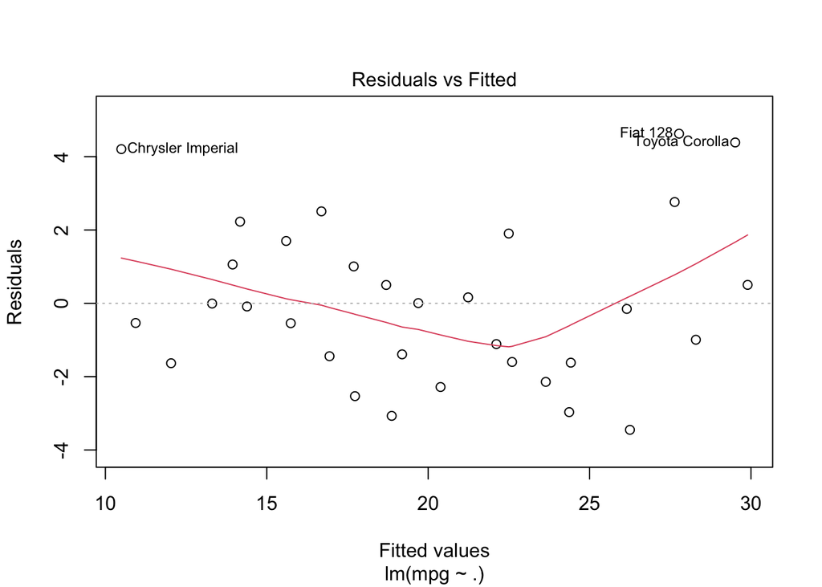

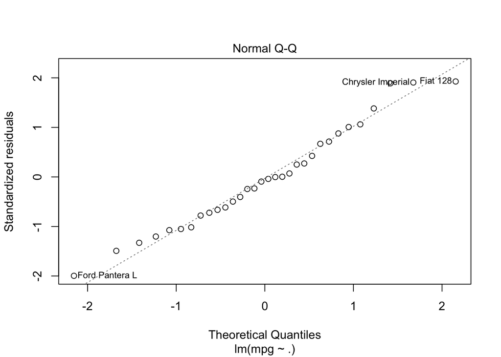

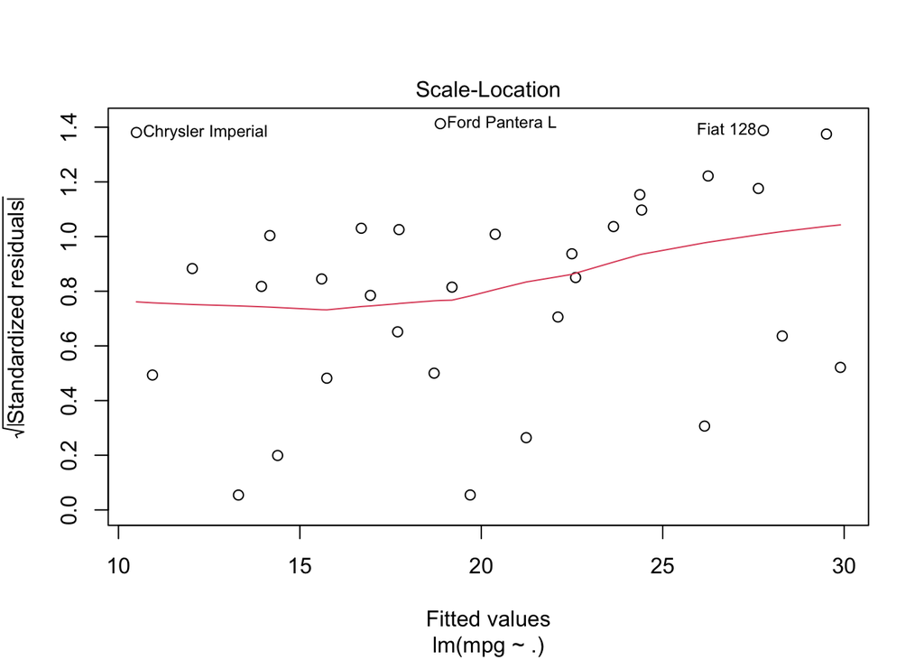

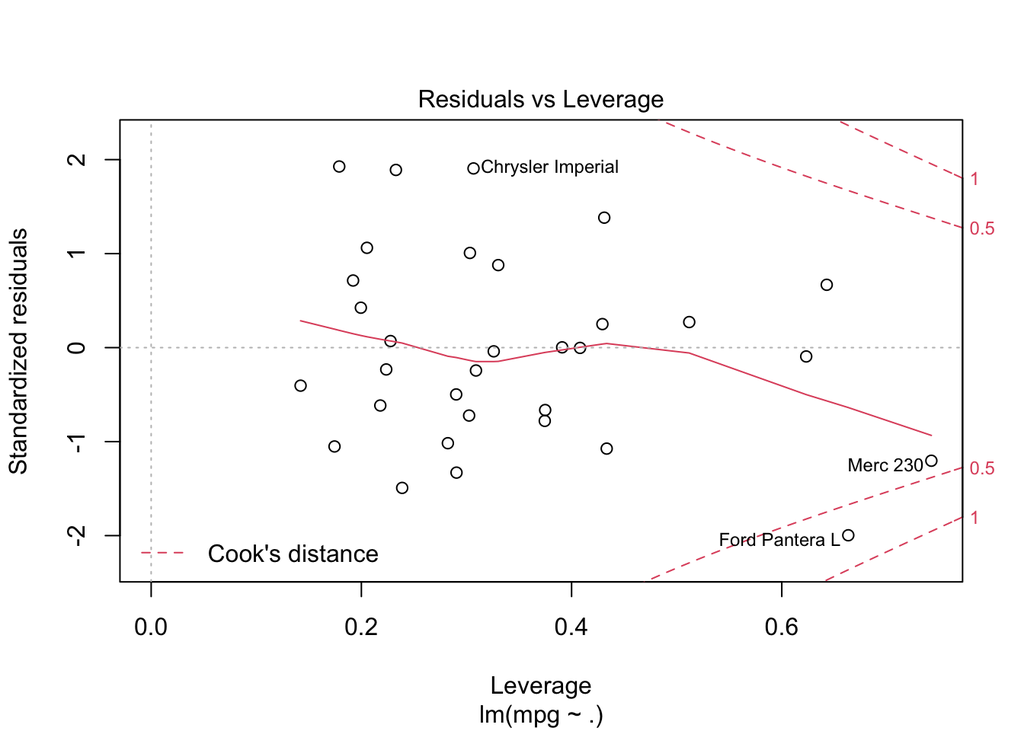

```r
mpg_model <- lm(mpg~., data = mt)

plot(mpg_model)
```

We did a bit of investigation based on a hunch about what would contribute to the fuel efficiency of a car, but we haven’t included all of the possible predictors yet. Let’s take our full model and toss it into an ANOVA to see what good predictors we missed.

```r
anova(mpg_model)
```

```
## Analysis of Variance Table
##
## Response: mpg
##           Df Sum Sq Mean Sq  F value    Pr(>F)
## cyl        1 817.71  817.71 116.4245 5.034e-10 ***
## disp       1  37.59   37.59   5.3526  0.030911 *
## hp         1   9.37    9.37   1.3342  0.261031
## drat       1  16.47   16.47   2.3446  0.140644
## wt         1  77.48   77.48  11.0309  0.003244 **
## qsec       1   3.95    3.95   0.5623  0.461656
## vs         1   0.13    0.13   0.0185  0.893173
## am         1  14.47   14.47   2.0608  0.165858
## gear       1   0.97    0.97   0.1384  0.713653
## carb       1   0.41    0.41   0.0579  0.812179
## Residuals 21 147.49    7.02
## ---
## Signif. codes:  0 '***' 0.001 '**' 0.01 '*' 0.05 '.' 0.1 ' ' 1
```

Of course! It makes sense that weight would also have some impact on fuel efficiency. We now know that our minimal model would include weight, the number of cylinders, and displacement.

```r
minimal_model_formula <- as.formula('mpg~wt*disp*cyl')

lm(minimal_model_formula, data=mt) %>% summary()
```

```
##
## Call:
## lm(formula = minimal_model_formula, data = mt)
##
## Residuals:
##     Min      1Q  Median      3Q     Max
## -2.5706 -1.7426 -0.3743  1.4873  4.0740
##
## Coefficients:
##               Estimate Std. Error t value Pr(>|t|)
## (Intercept) 107.715849  23.319435   4.619 0.000109 ***
## wt          -24.764727   8.472024  -2.923 0.007444 **
## disp         -0.593252   0.212642  -2.790 0.010165 *
## cyl         -10.814193   4.344206  -2.489 0.020126 *
## wt:disp       0.184476   0.068496   2.693 0.012702 *
## wt:cyl        2.906307   1.417577   2.050 0.051422 .
## disp:cyl      0.075185   0.026794   2.806 0.009791 **
## wt:disp:cyl  -0.023313   0.008608  -2.708 0.012271 *
## ---
## Signif. codes:  0 '***' 0.001 '**' 0.01 '*' 0.05 '.' 0.1 ' ' 1
##
## Residual standard error: 2.214 on 24 degrees of freedom
## Multiple R-squared:  0.8955, Adjusted R-squared:  0.8651
## F-statistic:  29.4 on 7 and 24 DF,  p-value: 2.754e-10
```

Not too bad. Now let’s do the same formula, but using glm instead of lm. You will notice that these are functionally the same, but the glm family argument allows us to do things like Poisson regression when the response variable is a count, or logistic regression when the response is a binary.

```r
glm(minimal_model_formula, data = mt, family = gaussian) %>% summary()
```

```
##
## Call:
## glm(formula = minimal_model_formula, family = gaussian, data = mt)
##
## Deviance Residuals:
##     Min       1Q   Median       3Q      Max
## -2.5706  -1.7426  -0.3743   1.4873   4.0740
##
## Coefficients:
##               Estimate Std. Error t value Pr(>|t|)
## (Intercept) 107.715849  23.319435   4.619 0.000109 ***
## wt          -24.764727   8.472024  -2.923 0.007444 **
## disp         -0.593252   0.212642  -2.790 0.010165 *
## cyl         -10.814193   4.344206  -2.489 0.020126 *
## wt:disp       0.184476   0.068496   2.693 0.012702 *
## wt:cyl        2.906307   1.417577   2.050 0.051422 .
## disp:cyl      0.075185   0.026794   2.806 0.009791 **
## wt:disp:cyl  -0.023313   0.008608  -2.708 0.012271 *
## ---
## Signif. codes:  0 '***' 0.001 '**' 0.01 '*' 0.05 '.' 0.1 ' ' 1
##
## (Dispersion parameter for gaussian family taken to be 4.900755)
##
##     Null deviance: 1126.05  on 31  degrees of freedom
## Residual deviance:  117.62  on 24  degrees of freedom
## AIC: 150.47
##
## Number of Fisher Scoring iterations: 2
```

We can also check out which cars are influencing our model (and get a ton of diagnostics).

```r
mt_influence <- influence.measures(lm(minimal_model_formula, data=mt))
mt_influence
```

```
## Influence measures of
##   lm(formula = minimal_model_formula, data = mt) :
##
##                       dfb.1_   dfb.wt dfb.disp  dfb.cyl dfb.wt.d dfb.wt.c
## Mazda RX4           -0.44559  0.33566  0.25048  0.51813 -0.23672 -0.42434
## Mazda RX4 Wag       -0.24458  0.18738  0.10549  0.29564 -0.10297 -0.23832
## Datsun 710           0.14875 -0.18412 -0.28019 -0.03864  0.29971  0.08758
## Hornet 4 Drive       0.40239 -0.68513 -0.10432 -0.34726  0.42366  0.55177
## Hornet Sportabout   -0.01426  0.05450 -0.04699  0.02587  0.02116 -0.08064
## Valiant             -0.50761  0.61350  0.44514  0.39074 -0.60929 -0.49950
## Duster 360          -0.01188 -0.01748  0.02450  0.01813 -0.00850  0.02017
## Merc 240D            0.03713  0.08729 -0.10785 -0.09130  0.07304 -0.02835
## Merc 230            -0.00386  0.03320 -0.01395 -0.01000  0.00216 -0.01769
## Merc 280            -0.01216  0.01034  0.02721  0.00517 -0.02627 -0.00875
## Merc 280C           -0.06707  0.05701  0.15008  0.02849 -0.14489 -0.04824
## Merc 450SE           0.17703 -0.17885  0.09062 -0.30805 -0.08234  0.33644
## Merc 450SL           0.03615 -0.04180  0.03802 -0.07630 -0.04537  0.09932
## Merc 450SLC         -0.01471  0.01612 -0.01221  0.02881  0.01369 -0.03529
## Cadillac Fleetwood   0.11469 -0.10619  0.01085 -0.18277 -0.00801  0.18544
## Lincoln Continental  0.05660 -0.04341 -0.01456 -0.08536  0.01108  0.07425
## Chrysler Imperial    0.04002 -0.05356  0.06884 -0.07753 -0.04995  0.09389
## Fiat 128             0.17693  0.12905 -0.48306 -0.03632  0.25241 -0.16305
## Honda Civic         -0.41654  0.40987  0.38658  0.24693 -0.40650 -0.27835
## Toyota Corolla       0.46936 -0.34997 -0.61554 -0.23693  0.54653  0.19611
## Toyota Corona        0.22220 -0.24034 -0.41631 -0.05364  0.41576  0.10350
## Dodge Challenger     0.00604 -0.00976  0.00207 -0.00635  0.00444  0.00883
## AMC Javelin          0.02981 -0.03184  0.00461 -0.04045  0.00855  0.03856
## Camaro Z28          -0.07212  0.04676 -0.00821  0.12068  0.01646 -0.09410
## Pontiac Firebird     0.10770 -0.01979 -0.05861 -0.15654  0.03731  0.03264
## Fiat X1-9           -0.24503  0.15732  0.29719  0.13063 -0.24349 -0.08981
## Porsche 914-2       -0.17953  0.11463  0.46362  0.02623 -0.40668 -0.00738
## Lotus Europa         0.04178 -0.08087  0.06440 -0.04756 -0.02925  0.07717
## Ford Pantera L       0.05480 -0.07798  0.04478 -0.09002 -0.02207  0.12344
## Ferrari Dino         0.03332 -0.02777 -0.01146 -0.04127  0.01332  0.03510
## Maserati Bora        0.00498 -0.00644 -0.00519 -0.00032  0.01407 -0.00354
## Volvo 142E           0.13966 -0.22820 -0.13875 -0.04899  0.19234  0.13816
##                     dfb.dsp. dfb.wt..   dffit cov.r   cook.d    hat inf
## Mazda RX4           -0.33270  0.30191  0.6061 1.786 0.046624 0.3669
## Mazda RX4 Wag       -0.15788  0.14174  0.3826 1.481 0.018650 0.2123
## Datsun 710           0.25470 -0.27914 -0.4974 1.009 0.030356 0.1457
```

[output cut: 14 more lines]

```
## Fiat 128             0.45003 -0.22710  1.1818 0.366 0.149365 0.2166
## Honda Civic         -0.37142  0.39394 -0.7107 1.468 0.063030 0.3273
## Toyota Corolla       0.58240 -0.51968  0.9025 1.102 0.098413 0.3082
## Toyota Corona        0.37627 -0.38440 -0.6130 1.036 0.045920 0.1950
## Dodge Challenger    -0.00419 -0.00322 -0.1067 1.490 0.001478 0.0926
## AMC Javelin         -0.00132 -0.01139 -0.1865 1.405 0.004476 0.1012
## Camaro Z28          -0.02679  0.00996 -0.3552 1.058 0.015677 0.0993
## Pontiac Firebird     0.13110 -0.06738  0.9338 0.521 0.097853 0.1894
## Fiat X1-9           -0.28258  0.23204 -0.6135 0.972 0.045720 0.1817
## Porsche 914-2       -0.42541  0.37561  0.5883 1.819 0.044005 0.3692
## Lotus Europa        -0.05717  0.02318  0.2315 2.231 0.006965 0.3883   *
## Ford Pantera L      -0.04528  0.01033 -0.3979 1.679 0.020287 0.2750
## Ferrari Dino         0.01896 -0.01895 -0.0496 2.045 0.000321 0.3139   *
## Maserati Bora        0.00254 -0.01005 -0.1628 1.415 0.003420 0.0924
## Volvo 142E           0.11869 -0.17783 -0.4565 1.316 0.026218 0.1986
```

For an example of the logistic regression we can set our response to engine shape (v-shaped or inline).

```r
glm(vs~., family = binomial, data = mt) %>% broom::tidy()
```

```
## # A tibble: 11 × 5
##    term        estimate std.error   statistic p.value
##    <chr>          <dbl>     <dbl>       <dbl>   <dbl>
##  1 (Intercept)  81.2    15891238.  0.00000511    1.00
##  2 mpg           2.45      59794.  0.0000410     1.00
##  3 cyl         -39.1      294676. -0.000133      1.00
##  4 disp         -0.0193     8518. -0.00000226    1.00
##  5 hp            0.313     22828.  0.0000137     1.00
##  6 drat        -27.4      969603. -0.0000282     1.00
##  7 wt          -12.5      643670. -0.0000194     1.00
##  8 qsec         15.6      384501.  0.0000407     1.00
##  9 am          -45.6      363187. -0.000126      1.00
## 10 gear        -28.3      544806. -0.0000520     1.00
## 11 carb         17.9      297094.  0.0000602     1.00
```

Our model didn’t converge. That makes sense because we wouldn’t really expect for the other variables to have any impact on the shape of the engine. For our next tests, we are going to move on to using the chicks data.

##### Chick Weights

These data are from an experiment testing the effects of diets on chick weights over 21 days. We will start by getting an idea of the distribution of weights for each diet group over time.

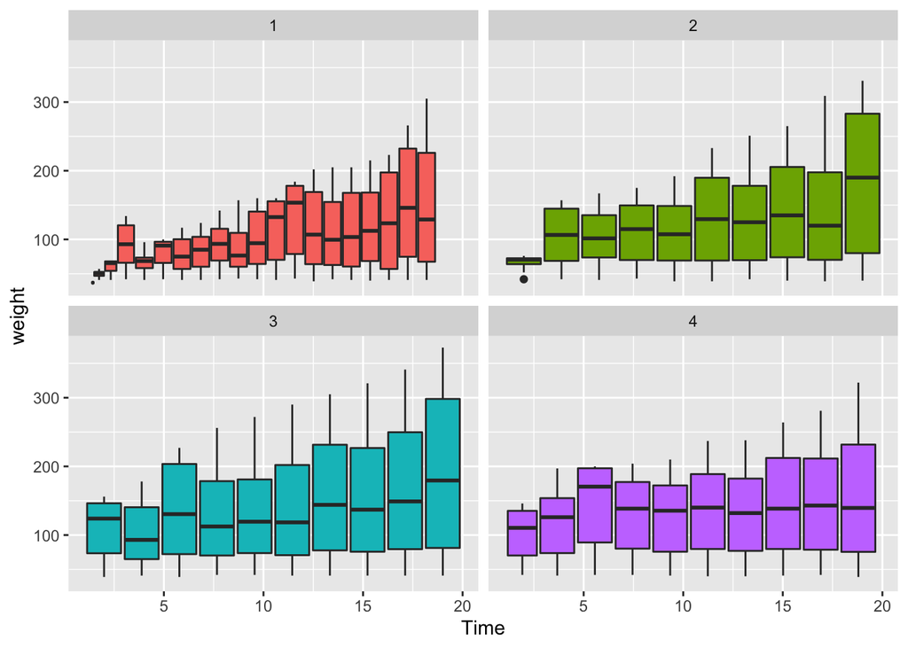

```r
ggplot(chicks) +
  geom_boxplot(aes(Time, weight, fill=Diet, group=Chick)) +
  facet_wrap(Diet~.) +
  guides(color='none', fill='none')
```

That looks fairly promising. There appears to be a definite difference in the weights. Though diets 2 and three look fairly similar. Let’s do a t-test to see if there is any significant difference in the two groups.

```r
chicks %>%
  filter(Diet %in% 2:3) %>%
  {t.test(weight~Diet, data=.)}
```

```
##
##  Welch Two Sample t-test
##
## data:  weight by Diet
## t = -1.983, df = 229.94, p-value = 0.04856
## alternative hypothesis: true difference in means between group 2 and group 3 is not equal to 0
## 95 percent confidence interval:
##  -40.5369562  -0.1297104
## sample estimates:
## mean in group 2 mean in group 3
##        122.6167        142.9500
```

According to the t-test results, we can be fairly confident that there is a difference in the weights between diet groups 2 and 3. Since these are time-wise observations on 4 separate groups of chicks it wouldn’t be meaningful to do a paired t-test. Just know that to do a paired t-test, all you have to do is set the `paired` argument to `TRUE`.

[^1]: I use the phrases “model equation” and “formula” interchangeably here because the former is preferred by statisticians whereas the latter is strictly the name of the object type in R parlance. It is my opinion that “formula” is more correct, but I am not a statistician by training.
[^2]: As in y~a*b
[^3]: Neural Networks: One of the most popular machine learning models. Also notoriously hard to validate without large amounts of labeled data.